# 201.8. SSSource table

For the Rubin Science Platform at data.lsst.cloud.  
Data Release: [Data Preview 2](https://dp2.lsst.io/)  
Container Size: Large  
LSST Science Pipelines version: r30.0.10  
Last verified to run: 2026-08-05  
Repository: github.com/lsst/tutorial-notebooks  
DOI: 10.11578/rubin/dc.20250909.20

**Learning objective:** To understand the contents of the `SSSource` table and how to access it.

**LSST data products:** `SSSource`

**Packages:** `lsst.rsp`, `lsst.daf.butler`, `lsst.utils.plotting`

**Credit:** Originally developed by the Rubin Community Science team. Please consider acknowledging them if this notebook is used for the preparation of journal articles, software releases, or other notebooks.

**Get Support:** Everyone is encouraged to ask questions or raise issues in the [Support Category](https://community.lsst.org/c/support) of the Rubin Community Forum. Rubin staff will respond to all questions posted there.

## 1. Introduction

The `SSSource` table contains single-epoch solar system source information corresponding to a specific difference image detection.

- TAP table name: `dp2.SSSource`
- butler table name: `ss_source`
- columns: 39
- rows: 8,136,150

**Related tutorials:** The TAP and butler data access services are demonstrated in the 100-level "How to" tutorials.

### 1.1. Import packages

Import standard python packages `numpy`, `matplotlib` and `astropy`.

From the `lsst` package, import modules for the TAP service, the butler, and plotting.

```python
import numpy as np
import matplotlib.pyplot as plt
import matplotlib.ticker as ticker
from lsst.rsp import RSPDiscovery
from lsst.daf.butler import Butler
from lsst.utils.plotting import (get_multiband_plot_colors,
                                 get_multiband_plot_symbols)
```

### 1.2. Define parameters and functions

Create an instance of the TAP service.

```python
discovery = RSPDiscovery("dp2")
service = discovery.get_tap_client()
```

Create an instance of the Rubin data butler.

```python
butler = Butler('dp2', collections="dp2")
```

Define the colors and symbols to represent the LSST filters in plots.

```python
filter_colors = get_multiband_plot_colors()
filter_names = filter_colors.keys()
filter_symbols = get_multiband_plot_symbols()
```

## 2. Schema (columns)

To browse the table schema visit the [Rubin schema browser](https://sdm-schemas.lsst.io/), or use the TAP service via the Portal Aspect or as demonstrated in Section 2.1.

### 2.1. Retrieve table schema

To retrieve the table schema, define a query for the schema columns of the `SSSource` table and run the query job.

```python
query = "SELECT column_name, datatype, description, unit " \
        "FROM tap_schema.columns " \
        "WHERE table_name = 'dp2.SSSource'"
job = service.submit_job(query)
job.run()
job.wait(phases=['COMPLETED', 'ERROR'])
print('Job phase is', job.phase)
if job.phase == 'ERROR':
    job.raise_if_error()
```

```
Job phase is COMPLETED
```

Retrieve the query results and display them as an `astropy` table with the `to_table()` attribute.

```python
assert job.phase == 'COMPLETED'
results = job.fetch_result().to_table()
results
```

*Table length=39*

| column_name str64 | datatype str64 | description str512 | unit str64 |
| --- | --- | --- | --- |
| diaSourceId | long | Unique identifier of the observation (matching DiaSource.diaSourceId). |  |
| ssObjectId | long | Unique LSST identifier of the Solar System object. |  |
| designation | char | The unpacked primary provisional designation for this object. |  |
| eclLambda | double | Ecliptic longitude, converted from the observed coordinates. | deg |
| eclBeta | double | Ecliptic latitude, converted from the observed coordinates. | deg |
| galLon | double | Galactic longitude, converted from the observed coordinates. | deg |
| galLat | double | Galactic latitude, converted from the observed coordinates. | deg |
| elongation | float | Solar elongation of the object at the time of observation. | deg |
| phaseAngle | float | Phase angle between the Sun, object, and observer. | deg |
| ... | ... | ... | ... |
| helio_vz | float | Cartesian heliocentric Z velocity at light-emission time (ICRS). | km/s |
| helio_vtot | float | The magnitude of the heliocentric velocity vector, sqrt(vx*vx + vy*vy + vz*vz). | km/s |
| topo_x | float | Cartesian topocentric X coordinate at light-emission time (ICRS). | AU |
| topo_y | float | Cartesian topocentric Y coordinate at light-emission time (ICRS). | AU |
| topo_z | float | Cartesian topocentric Z coordinate at light-emission time (ICRS). | AU |
| topo_vx | float | Cartesian topocentric X velocity at light-emission time (ICRS). | km/s |
| topo_vy | float | Cartesian topocentric Y velocity at light-emission time (ICRS). | km/s |
| topo_vz | float | Cartesian topocentric Z velocity at light-emission time (ICRS). | km/s |
| topo_vtot | float | The magnitude of the topocentric velocity vector, sqrt(vx*vx + vy*vy + vz*vz). | km/s |
| diaDistanceRank | short | The rank of the diaSourceId-identified source in terms of its closeness to the predicted SSO position. If diaSourceId is the nearest DiaSource to this SSO prediction, diaSourceDistanceRank=1 would be … |  |

The table displayed above has been truncated.

Option to print every column name as a list.

```python
# for col in results['column_name']:
#     print(col)
```

Delete the job, but not the `results`.

```python
del query
job.delete()
```

### 2.2. Key columns

Of the 39 columns of the `SSSource` table, several are the most commonly used.

#### 2.2.1. Solar System Object Id

The long integer that uniquely identifies each Solar System object:

- `ssObjectId`

#### 2.2.2. Unpacked primary provisional designation

The unpacked primary provisional designation for this object:

- `designation`

#### 2.2.3. Heliocentric distance and velocity

The cartesian heliocentric position and velocity coordinates:

- `helio_x`, `helio_y`, `helio_z`, `helio_vx`, `helio_vy`, `helio_vz`

The heliocentric distance at light-emission time and heliocentric radial velocity (positive values indicate motion away from the Sun):

- `helioRange`
- `helioRate`

The magnitude of the heliocentric velocity vector:

- `helio_vtot`

#### 2.2.4. Topocentric distance and velocity

The topocentric position and velocity coordinates:

- `topo_x`, `topo_y`, `topo_z`, `topo_vx`, `topo_vy`, `topo_vz`

The topocentric distance at light-emission time and topocentric radial velocity (positive values indicate motion away from the Sun):

- `topoRange`
- `topoRate`

The magnitude of the topocentric velocity vector:

- `topo_vtot`

#### 2.2.5. Phase angle and solar elongation

The phase angle is the angle between the light incident onto an observed object and the light reflected from the object:

- `phaseAngle`

The solar elongation at the time of observation:

- `elongation`

#### 2.2.6. Ecliptic coordinates

The ecliptic latitude and longitude, converted from the observed coordinates:

- `eclLambda`
- `eclBeta`

#### 2.2.7. Predicted magnitude, ra, dec, and on-sky angular rates

The predicted V-band magnitude, computed from mpc_orbits data including the mpc_orbits-provided (H, G) estimates:

- `ephVmag`

The predicted ICRS right ascension (ra) and declincation (dec) from the orbit in mpc_orbits:

- `ephRa`
- `ephDec`

The total predicted on-sky angular rate of motion and the predicted on-sky angular rates in the ra (includes the cos(dec) factor) and dec direction:

- `ephRate`
- `ephRateRa`
- `ephRateDec`

#### 2.2.8. Offsets from predicted magnitude, ra, dec, and on-sky angular rates

The total observed versus predicted angular separation on the sky and the offsets between the observed and predicted positions in the ra (includes cos(dec) term)and dec directions:

- `ephOffset`
- `ephOffsetRa`
- `ephOffsetDec`

The offsets between observed and predicted positions in the along-track and cross-track directions on the sky:

- `ephOffsetAlongTrack`
- `ephOffsetCrossTrack`

#### 2.2.9. Rank of source in its closeness to a predicted SSO position

For `diaSources` with known Solar System objects (SSOs) predicted to be within a 1 arcsecond association radius, the rank of the `diaSourceId` -identified source in terms of its closeness to the predicted SSO position:

- `diaDistanceRank`

I.e., if `diaSourceId` is the nearest `DiaSource` to the SSO prediction, `diaSourceDistanceRank` = 1 would be set. If it is the second nearest, it would be 2, etc. [Source association in DP2](https://dp2.lsst.io/processing/detection/index.html) provides more information.

### 2.3. Descriptions and units

For a subset of the key columns in Section 2.2, show the table of their descriptions and units.

```python
col_list = set(['ssObjectId', 'helioRange', 'topoRange', 'ephOffset'])
tx = [i for i, item in enumerate(results['column_name']) if item in col_list]
results[tx]
```

*Table length=4*

| column_name str64 | datatype str64 | description str512 | unit str64 |
| --- | --- | --- | --- |
| ssObjectId | long | Unique LSST identifier of the Solar System object. |  |
| topoRange | float | Topocentric distance (delta) at light-emission time. | AU |
| helioRange | float | Heliocentric distance (r) at light-emission time. | AU |
| ephOffset | float | Total observed versus predicted angular separation on the sky. | arcsec |

Clean up.

```python
del col_list, tx, results
```

## 3. Data access

The `SSSource` table is available via the TAP service and the butler.

**Recommended access method:** TAP.

### 3.1. TAP (Table Access Protocol)

The `SSSource` table is stored in Qserv and accessible via the TAP services using ADQL queries.

#### 3.1.1. Catalog size

Retrieve the size of the `SSSource` catalog.

```python
results = service.search("SELECT COUNT(*) FROM dp2.SSSource")
results.to_table()
```

*Table length=1*

| COUNT1 int64 |
| --- |
| 8136150 |

The `SSSource` table contains 8,136,150 Solar System sources. Querying the entire table results in long query times. To reduce query times, retrieve a subset of the data by `ssObjectId`.

#### 3.1.2. Retrieve a subset

To retrieve a subset of rows, use the `where` option in queries to select `ssObjectId` values within a range. By using `ssObjectId`, the query returns a subset of `SSSource` rows that are associated with a row in the `SSObject` table.

First, figure out the full range of `ssObjectId` values by using the ADQL `MIN` and `MAX` functions.

```python
results = service.search("SELECT min(ssObjectId), max(ssObjectId)"
                         "FROM dp2.SSSource")
results.to_table()
```

*Table length=1*

| min1 int64 | max2 int64 |
| --- | --- |
| 20606185051795521 | 6001945050679883312 |

```python
min_val = int(results[0].get('min1'))
max_val = int(results[0].get('max2'))
print('Full range: ', min_val, max_val)

max_val = int(min_val + 0.00005*(max_val-min_val))
print('Search range: ', min_val, max_val)
```

```
Full range:  20606185051795521 6001945050679883312
Search range:  20606185051795521 20905251995076924
```

#### 3.1.3. Demo query

Define a query to return three of the "key columns" from Section 2.2 for objects with `ssObjectId` values in the "search range" returned above.

Although it can take several minutes to retrieve the `SSSource` data for the full set of `SSObject` values, to retrieve all `SSSources`, use the following query:

[output not shown]

For more details on the observations of the DP2 Solar System objects, see tutorial 308.02 Observations.

```python
query = "SELECT ssObjectId, "\
        "helioRange, topoRange "\
        "FROM dp2.SSSource " \
        "WHERE ssObjectId BETWEEN "\
        "20606185051795521 "\
        "AND 20905251995076924 "\
        "ORDER BY ssObjectId ASC "
job = service.submit_job(query)
job.run()
job.wait(phases=['COMPLETED', 'ERROR'])
print('Job phase is', job.phase)
if job.phase == 'ERROR':
    job.raise_if_error()
```

```
Job phase is COMPLETED
```

Fetch the results as an `astropy` table. The random subset returns 511,980 Solar System sources. This is ~ 6% of the DP2 Solar System source measurements.

```python
assert job.phase == 'COMPLETED'
results = job.fetch_result().to_table()
print(len(results))
```

```
511980
```

Option to print the results.

```python
# results
```

Plot histograms of the heliocentric and topocentric distances for the subset (~6%) of DP2 Solar System sources out to 5 au.

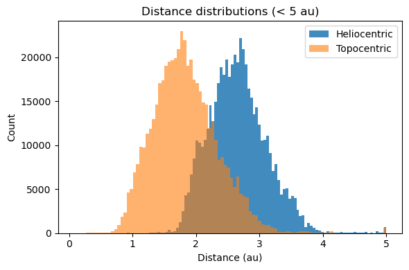

```python
fig, ax = plt.subplots(figsize=(6, 4))

ax.hist(results['helioRange'].clip(0, 5), bins=100,
        edgecolor='none', alpha=0.85, label='Heliocentric')
ax.hist(results['topoRange'].clip(0, 5), bins=100,
        edgecolor='none', alpha=0.6, label='Topocentric')
ax.set_xlabel('Distance (au)')
ax.set_ylabel('Count')
ax.set_title('Distance distributions (< 5 au)')
ax.legend()

plt.tight_layout()
plt.show()
```

> **Figure 1:** Histograms of the heliocentric and topocentric distances for a subset (~6%) of DP2 Solar System sources out to 5 au.

Clean up.

```python
job.delete()
del query, results
```

#### 3.1.4. Joinable tables

The `DiaSource` table contains information about the astrometric and photometric measurements for solar system objects detected in difference images.

With 8,136,150 source measurements of Solar System objects in DP2, the best way to demonstrate the difference image detections in the `SSSource` table is to look at just one `SSObject`. `ssObjectId` = `21163615737558602` has the largest number of detections in DP2.

Query the `SSSource` table for the topocentric distance (`topoRange`) adding a table join to the `DiaSource` table and retrieving the `midpointMjdTai` column for the observation midpoint of the source measurements for `ssObjectId` = `21163615737558602`.

```python
query = "SELECT sss.ssObjectId, "\
        "sss.topoRange, dia.midpointMjdTai, "\
        "dia.band "\
        "FROM dp2.SSSource as sss " \
        "JOIN dp2.DiaSource as dia "\
        "ON sss.diaSourceId = dia.diaSourceId " \
        "WHERE sss.ssObjectId = 21163615737558602 "
job = service.submit_job(query)
job.run()
job.wait(phases=['COMPLETED', 'ERROR'])
print('Job phase is', job.phase)
if job.phase == 'ERROR':
    job.raise_if_error()
```

```
Job phase is COMPLETED
```

Fetch the results as an `astropy` table. `ssObjectId` = `21163615737558602` has 732 source measurements.

```python
assert job.phase == 'COMPLETED'
results = job.fetch_result().to_table()
print(len(results))
```

```
732
```

Option to print the results.

```python
# results
```

Plot topocentric distance as a function of the observation midpoint for `ssObjectId` = `21163615737558602`.

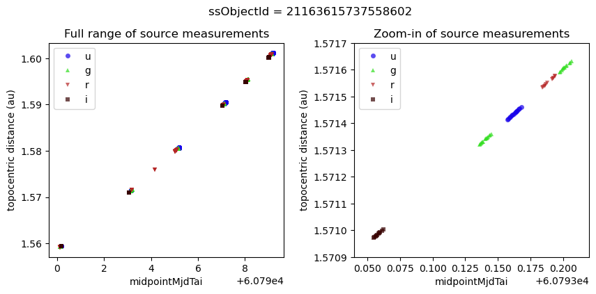

```python
fig, ax = plt.subplots(1, 2, figsize=(10, 4))
for filt in filter_names:
    fx = np.where(results['band'] == filt)[0]
    if len(fx) > 0:
        ax[0].plot(results['midpointMjdTai'][fx],
                   results['topoRange'][fx],
                   filter_symbols[filt], ms=5, mew=0, alpha=0.7,
                   color=filter_colors[filt], label=filt)
        ax[0].set_xlabel('midpointMjdTai')
        ax[0].set_ylabel('topocentric distance (au)')
        ax[0].set_title('Full range of source measurements')
        ax[0].legend(loc='upper left')
        ax[1].plot(results['midpointMjdTai'][fx],
                   results['topoRange'][fx],
                   filter_symbols[filt], ms=5, mew=0, alpha=0.7,
                   color=filter_colors[filt], label=filt)
        ax[1].set_xlim(60793.04, 60793.22)
        ax[1].set_ylim(1.5709, 1.5717)
        ax[1].set_xlabel('midpointMjdTai')
        ax[1].set_ylabel('topocentric distance (au)')
        ax[1].set_title('Zoom-in of source measurements')
        ax[1].legend(loc='upper left')

plt.subplots_adjust(wspace=0.3)
plt.suptitle(f"ssObjectId = {results['ssObjectId'][0]}",
             y=1.01)
plt.show()
```

> **Figure 2:** Left: topocentric distance as a function of the observation midpoint for `ssObjectId` = `21163615737558602`, with colors and symbols to represent the four filters (ugri) obtained on the nights of MJD = 60790 - 60799. Right: similar to left panel but zoomed-in on the night of MJD = 60793. The topocentric distance of `ssObjectId` = `21163615737558602` increases with observation date.

Clean up.

```python
job.delete()
del query, results
```

### 3.2. Butler

TAP is the recommended way to access the solar system source table, but the butler can be used to retrieve the same table information.

#### 3.2.1. Demo query

Define the columns to retrieve.

```python
col_list = ['ssObjectId', 'topoRange', 'phaseAngle']
```

Get the data from the butler.

```python
results = butler.get('ss_source', parameters={'columns': col_list})
print(len(results))
```

```
8136150
```

Option to display the results.

```python
# results
```

Plot the phase angle as a function of topocentric distance for every DP2 Solar System source.

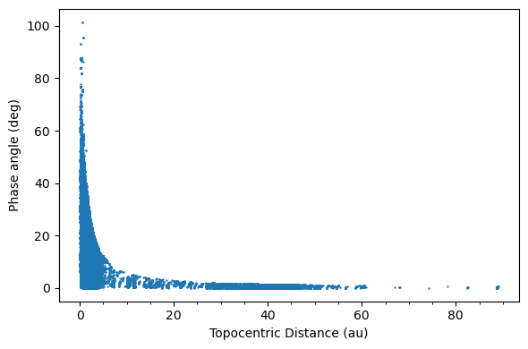

```python
fig, ax = plt.subplots(figsize=(6, 4))
ax.scatter(results['topoRange'], results['phaseAngle'], s=0.5)
plt.xlabel('Topocentric Distance (au)')
plt.ylabel('Phase angle (deg)')
plt.tight_layout()
ax.xaxis.set_minor_locator(ticker.MultipleLocator(5))
plt.show()
```

> **Figure 3:** Phase angle as a function of topocentric distance for every DP2 Solar System source. Only relatively nearby objects are observed at high phase angles.

Clean up.

```python
del col_list, results
```